# TITULO

### Matriz de Correlación

Las matrices de correlación nos calculan el coeficiente de Pearson entre un abanico continuo de -1 (relación inversa total) a 1 (relación directa total). Las correlaciones por encima de 0.7 nos advierten de redundancias importantes.

```r
# 1. Filtramos solo las variables que son numéricas
nums <- sapply(Diabetes_B, is.numeric)
data_num <- Diabetes_B[, nums]
# 2. Calculamos la matriz de correlación
cor_mat <- cor(data_num, use = "complete.obs")
# 3. Vamos a filtrar la matriz e imprimir solo las parejas con Correlación Mayor a 0.5 (Alta correlación)
cor_mat[lower.tri(cor_mat, diag=TRUE)] <- NA
high_cor <- which(abs(cor_mat) > 0.5, arr.ind = TRUE)
cat("Parejas de Variables Altamente Correlacionadas\n")
```

```
## Parejas de Variables Altamente Correlacionadas
```

```r
for(i in 1:nrow(high_cor)){
    cat(rownames(cor_mat)[high_cor[i,1]], "-", colnames(cor_mat)[high_cor[i,2]],
        ":", round(cor_mat[high_cor[i,1], high_cor[i,2]], 2), "\n")
}
```

```
## glucose - insulin : 0.59
## triceps - mass : 0.66
## pregnant - age : 0.7
## mass - CRP : 0.61
```

- `pregnant - age : 0.70` A mayor edad, es predecible una mayor cantidad de embarazos en el histórico
- `triceps - mass : 0.66` El grosor del pliegue cutáneo del tríceps avanza predeciblemente con la masa corporal general
- `mass - CRP : 0.61` La proteína C Reactiva escala de la mano con el Índice de Masa Corporal
- `glucose - insulin : 0.59` Niveles altos de glucosa correlacionan con niveles de insulina

La pareja **pregnant-age** se acerca al umbral crítico del 0.75-0.80, una de las dos variables podría llegar a eliminarse.

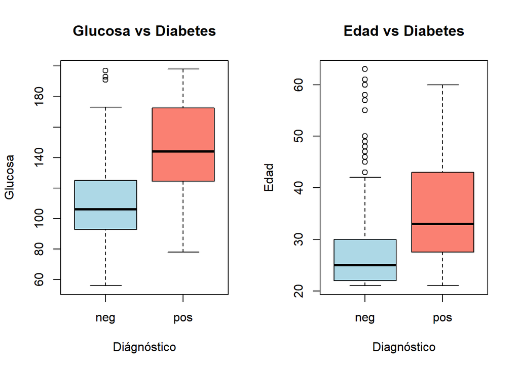

| diabetes | glucose |
| --- | --- |
| neg | 110.5565 |
| pos | 145.3496 |

Al observar los diagramas que genera R y ver la tabla de medias de glucosa (neg: 110.5, pos: 145.3), comprobamos de manera super evidente que la **glucosa es un excelente predictor**. Los enfermos diagnosticados positivamente tienen la línea base de la caja notoriamente elevada y se superponen muy poco con el grueso de pacientes negativos. La edad, sin embargo, muestra cajas mucho más solapadas (impacta menos en el resultado global).

###Análisis Bivariado (Categórica vs. Categórica)

```
## --- Frecuencias Absolutas ---
```

```
##
##       neg pos
##   No  170  84
##   Yes  78  39
```

```
##
## --- Proporciones por Fila (Sabiendo la Dieta, ¿qué % es Diabético?) ---
```

```
##
##         neg   pos
##   No  66.93 33.07
##   Yes 66.67 33.33
```

Se observa con este analisis que la variable `vegdiet` es totalmente **inútil** para predecir si alguien tendrá diabetes. Podría ser candidata a ser desechada sin afectar al aprendizaje general.

# Análisis de Componentes Principales

## Tratamiento de los datos

Para la ejecución del modelo PCA, se han seleccionado exclusivamente las *variables de naturaleza numérica*, ya que este análisis se basa en el cálculo de varianzas y covarianzas que requieren datos continuos. Se han excluido las variables categóricas, como la dieta (vegdiet) y el diagnóstico final (diabetes), con el fin de que la estructura de las componentes principales se construya únicamente a partir de los biomarcadores metabólicos y antropométricos. Esto nos permitirá observar cómo la variabilidad biológica de las pacientes agrupa los datos de forma natural antes de contrastarlos con el diagnóstico real.

```
## Variables/Observaciones eliminadas:
```

```
## $Variables
##       Variable Model Problem
## 1     pregnant
## 2      glucose
## 3     pressure
## 4      triceps
## 5      insulin
## 6         mass
## 7     pedigree
## 8          age
## 9  cholesterol
## 10      leptin
## 11         CRP
##
## $Observations
## [1] Observation Problem
## <0 rows> (o 0- extensión row.names)
```

Tras aplicar el filtrado, se confirma que la base de datos mantiene las 371 observaciones, lo que indica la ausencia de valores faltantes (NAs) críticos que impidieran el análisis.

```
##     pregnant         glucose         pressure         triceps
##  Min.   : 0.000   Min.   : 56.0   Min.   : 24.00   Min.   : 7.00
##  1st Qu.: 1.000   1st Qu.: 99.0   1st Qu.: 62.00   1st Qu.:21.00
##  Median : 2.000   Median :119.0   Median : 70.00   Median :29.00
##  Mean   : 3.272   Mean   :122.1   Mean   : 70.79   Mean   :28.93
##  3rd Qu.: 5.000   3rd Qu.:143.0   3rd Qu.: 78.00   3rd Qu.:37.00
##  Max.   :15.000   Max.   :198.0   Max.   :110.00   Max.   :63.00
##     insulin           mass          pedigree           age
##  Min.   : 14.0   Min.   :18.20   Min.   :0.0850   Min.   :21.0
##  1st Qu.: 76.0   1st Qu.:28.40   1st Qu.:0.2685   1st Qu.:23.0
##  Median :126.0   Median :33.20   Median :0.4460   Median :27.0
##  Mean   :154.7   Mean   :33.06   Mean   :0.5215   Mean   :30.6
##  3rd Qu.:190.0   3rd Qu.:37.05   3rd Qu.:0.6800   3rd Qu.:36.0
##  Max.   :744.0   Max.   :67.10   Max.   :2.4200   Max.   :63.0
##   cholesterol        leptin            CRP
##  Min.   :100.0   Min.   : 0.350   Min.   :1.460
##  1st Qu.:185.1   1st Qu.: 7.210   1st Qu.:2.860
##  Median :203.8   Median : 8.860   Median :3.390
##  Mean   :204.8   Mean   : 9.071   Mean   :3.539
##  3rd Qu.:226.0   3rd Qu.:10.780   3rd Qu.:4.100
##  Max.   :317.9   Max.   :17.180   Max.   :8.430
```

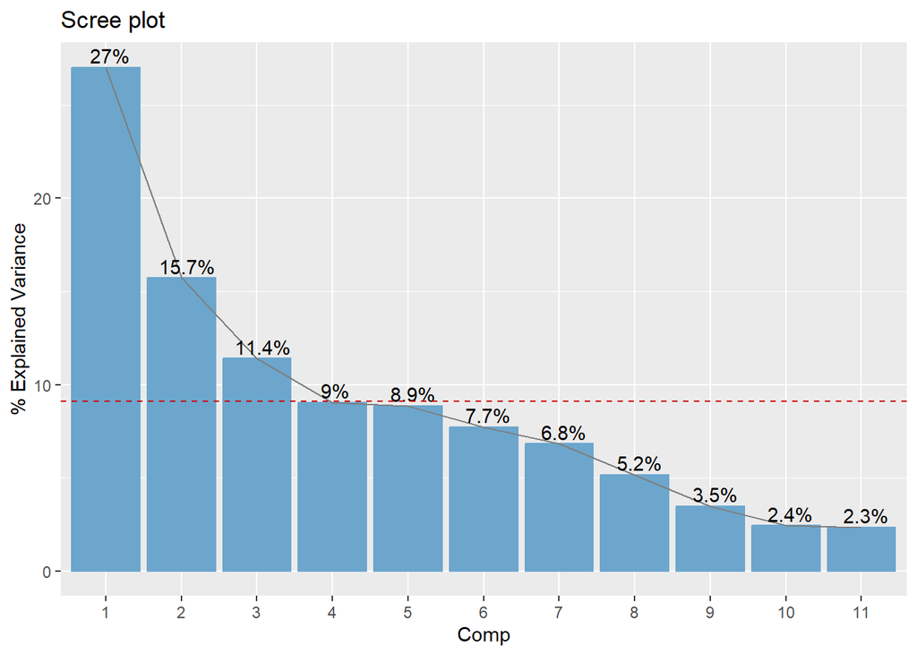

# Reglas de asociación [OPCIONAL. 2 páginas máximo]

# Análisis Factorial de Correspondencias [OPCIONAL. 2 páginas máximo]